# Wykrywanie fraudów w sieci Ethereum

Projekt z przedmiotu Eksploracja danych

Aliaksei Karatysh

2026-06-26

# Wykrywanie fraudów w sieci Ethereum

Binarna klasyfikacja kont Ethereum: **fraud** vs **legit**

## Problem predykcyjny i dane

**Cel:** odróżnić konta fraudowe (`FLAG = 1`) od legalnych (`FLAG = 0`) na podstawie statystyk aktywności transakcyjnej.

- zbiór **Ethereum Fraud Detection** (Kaggle): **9 841** kont × **51** cech
- cechy: liczba i częstotliwość transakcji, wartości w ETH, saldo, statystyki tokenów **ERC20**
- typ zadania: **binarna klasyfikacja**, klasa pozytywna = *fraud*

Najważniejsza właściwość zbioru — **niezbalansowanie klas** — kształtuje wszystkie dalsze decyzje metodyczne.

## Niezbalansowanie klas

```r
df %>% count(FLAG) %>% mutate(procent = round(100 * n / sum(n), 1))
```

```
  FLAG    n procent
1    0 7662    77.9
2    1 2179    22.1
```

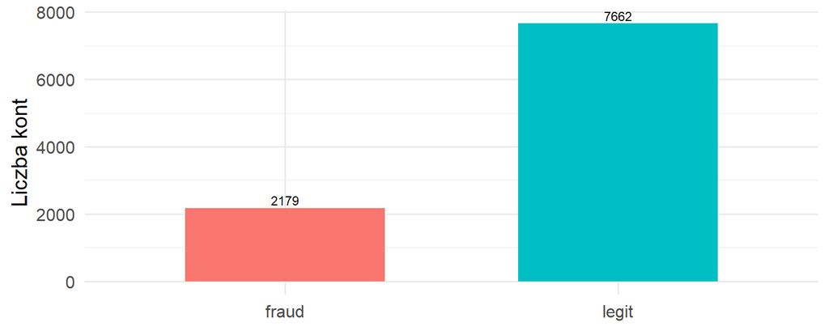

Klasa *fraud* to tylko ~22% obserwacji. Model zawsze przewidujący „legit” miałby ~78% accuracy → **accuracy jest myląca**, używamy **recall, precision, ROC AUC**, a na treningu — **SMOTE**.

## Przegląd literatury

Wykrywanie fraudów w blockchainie to aktywny obszar badań. Trzy główne nurty:

- **Klasyczne ML na cechach zagregowanych** *(nasze podejście)* — lasy losowe i XGBoost regularnie osiągają **ROC AUC > 0,95**. Farrugia i in. (2020), autorzy wykorzystywanego zbioru, wskazali liczbę transakcji ERC20 i statystyki czasowe jako kluczowe predyktory.
- **Metody grafowe (GNN)** — modelują sieć transakcji jako graf powiązań (np. *trans2vec*); Weber i in. (2019) na zbiorze Elliptic dla Bitcoina.
- **Wykrywanie anomalii** — bez etykiet (Isolation Forest, autoenkodery), fraud jako obserwacja odstająca.

Świadomie wybieramy **nurt klasyczny** — odpowiada naturze zbioru (cechy zagregowane, nie graf) i zakresowi technik z zajęć.

Farrugia i in. (2020), *Detection of illicit accounts over the Ethereum blockchain*, ESWA 150 · Weber i in. (2019), *Anti-Money Laundering in Bitcoin*, KDD Workshop · Chen & Guestrin (2016), *XGBoost*, KDD · Chawla i in. (2002), *SMOTE*, JAIR 16

## Czyszczenie i selekcja cech

```r
df_clean <- df %>%
  select(-1, -Index, -Address) %>%          # usunięcie identyfikatorów
  janitor::clean_names() %>%                 # ujednolicenie nazw
  mutate(flag = factor(flag, levels = c(1,0),
                       labels = c("fraud","legit")))

# usunięcie cech o zerowej wariancji (stałych)
df_clean <- df_clean %>% select(-any_of(zero_var_cols))
# usunięcie jednej cechy z każdej pary o |korelacji| > 0,9
df_clean <- df_clean %>% select(-any_of(high_corr))
```

Braki danych występują tylko w kolumnach ERC20 (~8%) i mają charakter **strukturalny** — to konta, które nigdy nie operowały tokenami ERC20. Dlatego uzupełniamy je **zerem** (brak aktywności = 0), co jest spójne z ich znaczeniem.

## Macierz korelacji cech

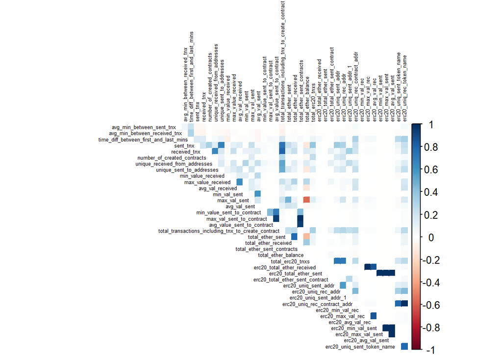

**Jak czytać:** kolor = siła i znak korelacji (granat = silna dodatnia, czerwień = ujemna). Widoczne **bloki** silnie powiązanych cech — grupa statystyk **ERC20** oraz grupa cech **wartości transakcji**. Te redundantne cechy usuwamy (|r| > 0,9), bo niosą tę samą informację i szkodzą modelom liniowym. Większość pozostałych cech jest słabo skorelowana → niosą **komplementarną** informację.

## Ograniczenia analizy

Świadomie przyjęte ograniczenia:

- **Usunięty typ tokenu.** Tekstowe kolumny typu tokenu ERC20 usunęliśmy (dużo kategorii + braki), choć mogą nieść sygnał — fraudy bywają związane ze specyficznymi tokenami. Pomogłoby grupowanie rzadkich kategorii lub *target encoding*.

## Rozkłady cech względem klasy

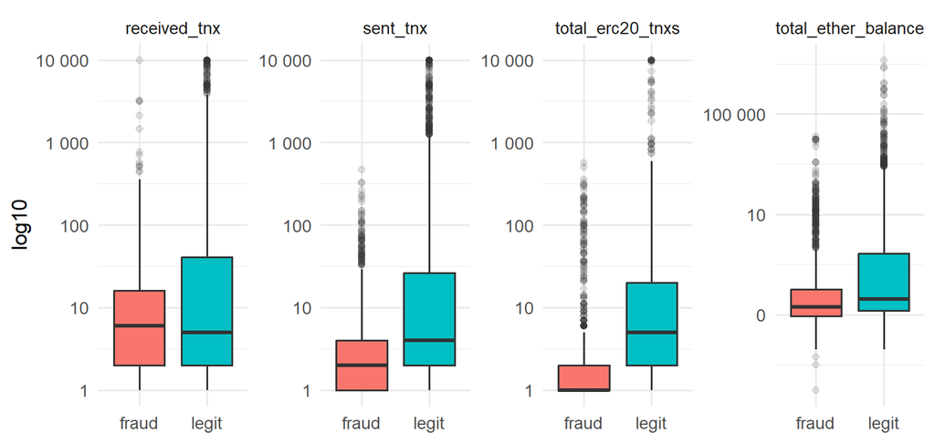

**Reprezentatywny przekrój** podstawowych cech (po jednej z grup: wysłane, odebrane, saldo, ERC20) — formalny wybór ważnych cech robi później VIP. **Skala logarytmiczna**, bo cechy mają rozkład silnie prawostronnie skośny (od jedności do dziesiątek tysięcy) — w skali liniowej 95% obserwacji ścisnęłoby się przy zerze. W skali log widać **systematyczne różnice** rozkładów między klasami — to predykcyjna podstawa modeli.

# Przygotowanie i modelowanie

## Recipe

```r
# Braki strukturalne ERC20 (brak aktywności) uzupełniamy zerem
df_clean <- df_clean %>% mutate(across(starts_with("erc20"), ~replace_na(., 0)))

set.seed(2026)
splits     <- initial_split(df_clean, prop = 0.8, strata = flag)  # podział 80/20
train_data <- training(splits)
test_data  <- testing(splits)

fraud_recipe <- recipe(flag ~ ., data = train_data) %>%
  step_impute_median(all_numeric_predictors()) %>%  # zabezpieczenie dla reszty
  step_zv(all_numeric_predictors()) %>%             # usunięcie cech stałych
  step_normalize(all_numeric_predictors()) %>%      # skalowanie
  step_smote(flag, over_ratio = 0.5, seed = 2026)   # balansowanie

cv_folds <- vfold_cv(train_data, v = 5, strata = flag)
```

Podział **przed** transformacjami; przepis uczony **wyłącznie na treningu** i przeliczany w każdym foldzie CV → ocena jest uczciwa.

## Cztery rodziny modeli

```r
# 1) Regresja logistyczna z regularyzacją L1 (Lasso)
log_model <- logistic_reg(penalty = tune(), mixture = 1) %>%
  set_engine("glmnet") %>% set_mode("classification")

# 2) Las losowy
rf_model  <- rand_forest(mtry = tune(), trees = 200, min_n = tune()) %>%
  set_engine("ranger", importance = "impurity") %>% set_mode("classification")

# 3) XGBoost (gradient boosting)
xgb_model <- boost_tree(trees = tune(), learn_rate = tune(), tree_depth = tune()) %>%
  set_engine("xgboost") %>% set_mode("classification")

# 4) Sieć neuronowa MLP
mlp_model <- mlp(hidden_units = 10, penalty = 0.01, epochs = 100) %>%
  set_engine("nnet") %>% set_mode("classification")
```

Model liniowy, dwa drzewiaste i sieć neuronowa — porównujemy, który typ najlepiej radzi sobie z problemem. **Las losowy** buduje wiele drzew niezależnie (uśrednia głosy → mniejsza wariancja), **XGBoost** buduje drzewa sekwencyjnie (każde poprawia błędy poprzednich → mniejsze obciążenie). Regresję, las losowy i XGBoost **stroimy**; MLP traktujemy jako **baseline** bez strojenia (na danych tabelarycznych drzewa zwykle wygrywają, a strojenie sieci jest kosztowne).

## Strojenie hiperparametrów

```r
class_metrics <- metric_set(roc_auc, f_meas, recall, precision, accuracy)

rf_results <- tune_grid(
  rf_wf,
  resamples = cv_folds,
  grid = grid_random(mtry(range = c(3, 15)),
                     min_n(range = c(2, 20)), size = 6),
  metrics = class_metrics,
  control = control_grid(save_pred = TRUE)
)
best_rf <- select_best(rf_results, metric = "roc_auc")    # wybór najlepszego
```

Każda konfiguracja oceniana **5-krotną walidacją krzyżową**, wybór wg **ROC AUC**. Analogicznie dla regresji i XGBoost.

## Najlepsze hiperparametry (z CV)

| Model | Parametry |
| --- | --- |
| Regresja log. | penalty = 1e-04 |
| Las losowy | mtry = 8, min_n = 6 |
| XGBoost | trees = 320, tree_depth = 4, learn_rate = 0.0527 |

Wartości wybrane automatycznie przez `select_best()` na podstawie wyników walidacji krzyżowej.

# Wyniki i ewaluacja

## Porównanie modeli — Train vs Test

[output not shown]

Porównanie train vs test wykrywa **przeuczenie** (duża różnica train ≫ test). Najlepsze wyniki testowe: **las losowy i XGBoost** — je analizujemy dalej.

## Krzywe ROC i Precision-Recall

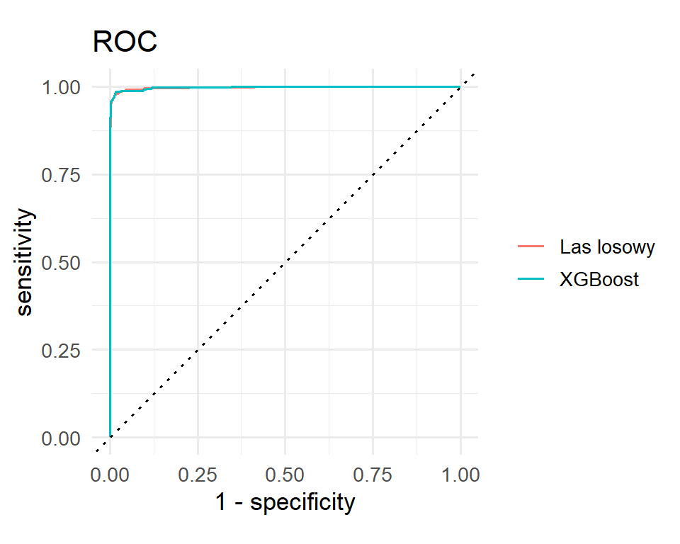

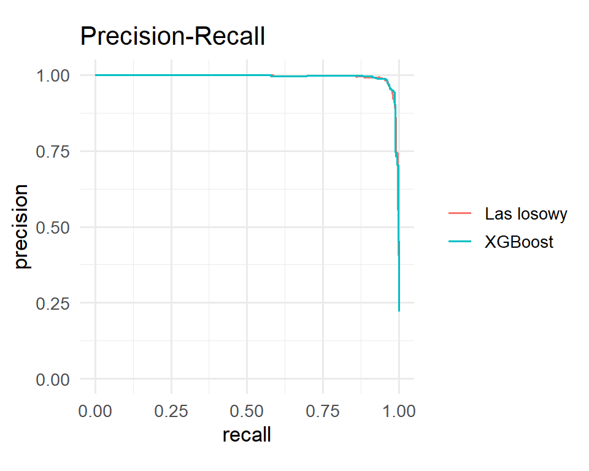

## Kalibracja i próg decyzyjny

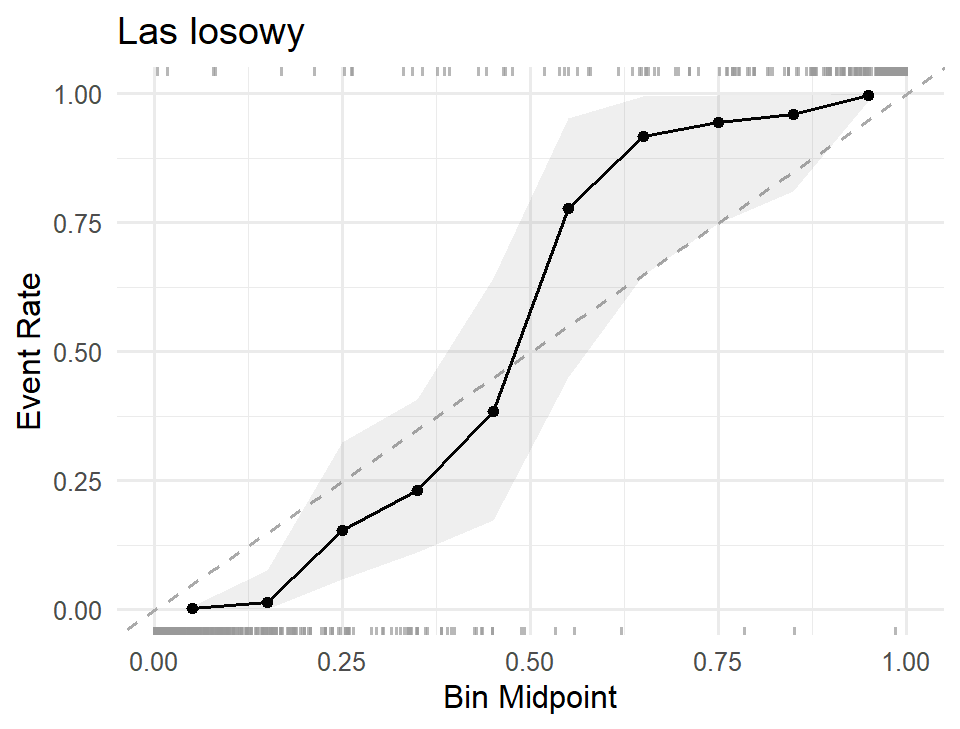

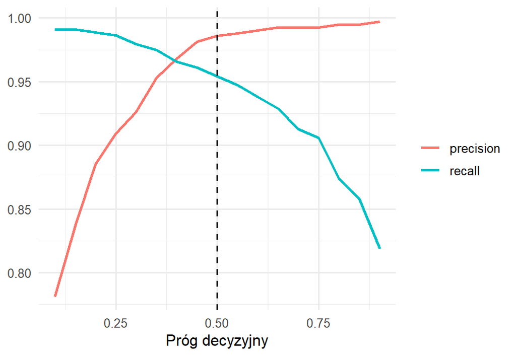

**Wykresy dla modelu Las losowy.** **Lewy (kalibracja)** — czy prawdopodobieństwa modelu są prawdziwe: oś X = co model przewidział, oś Y = jaka była rzeczywista częstość fraudów. Linia blisko przekątnej = dobra kalibracja. **Prawy (próg)** — domyślny próg 0,5 **nie jest optymalny**: niżej = wyższy recall, ale niższa precyzja. Przeoczony fraud jest kosztowniejszy niż fałszywy alarm, więc warto obniżyć próg w okolice maksimum F1.

## Analiza błędów (Las losowy)

| Typ predykcji | Liczba | Procent |
| --- | --- | --- |
| Fałszywie negatywny (przeoczony fraud) | 20 | 1.02 |
| Fałszywie pozytywny (fałszywy alarm) | 6 | 0.30 |
| Poprawna | 1943 | 98.68 |

## Wyjaśnialność — ważność cech (VIP)

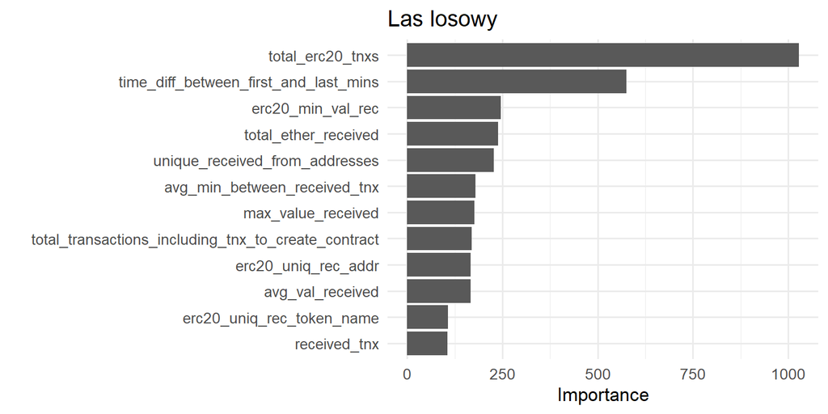

Najsilniejsze predyktory: aktywność **ERC20**, statystyki **czasowe** i **wolumenowe**.

# Wnioski

## Podsumowanie i wdrożenie

**Wnioski:**

- najlepsze modele: **XGBoost i las losowy** (ROC AUC na poziomie literaturowym), lepsze od regresji i MLP
- kluczowe predyktory: aktywność **ERC20**, cechy **czasowe** i **wolumenowe**
- domyślny próg **0,5 nie jest optymalny** — obniżenie zwiększa recall (ważne przy koszcie przeoczonego fraudu)
- prawdopodobieństwa po SMOTE wymagają **ostrożnej interpretacji**

**Wdrożenie:** finalny XGBoost wytrenowany na całości danych, zapisany do pliku; funkcja zwraca P(fraud) + poziom ryzyka.

## Wdrożenie i test predykcyjny

Finalny **XGBoost** wytrenowany na całości danych, zapisany do pliku (`fraud_model.rds`). Funkcja produkcyjna zwraca prawdopodobieństwo fraudu i **poziom ryzyka**:

```r
predict_fraud(deployed_model, test_data %>% slice(1:5) %>% select(-flag)) %>%
  knitr::kable(digits = 3, col.names = c("P(fraud)", "Predykcja", "Poziom ryzyka"))
```

| P(fraud) | Predykcja | Poziom ryzyka |
| --- | --- | --- |
| 0.006 | legit | NISKIE |
| 0.000 | legit | NISKIE |
| 0.001 | legit | NISKIE |
| 0.001 | legit | NISKIE |
| 0.000 | legit | NISKIE |

Model działa **end-to-end**: dla nowego konta zwraca ocenę ryzyka (NISKIE / ŚREDNIE / WYSOKIE) gotową do użycia operacyjnego.